# TCC DO CURSO DE R

Cristine Ellen, Sarah Pontes e Yasmin Santana

2022-06-19

## Introdução

Análise de dados de projeçao do IBGE em 2018 e construção do mapa de distribuição da população por unidade de federação. Este relatório utiliza da base de projeção do IBGE em 2018 e do arquivo geoespacial por unidade de federação para fazer gráficos e análises.

## Pacotes

De início, todos os pacotes usado nesse relatório estarão aqui - tanto os pacotes utilizados para a análise dos dados quanto os do mapa.

```r
install.packages('dplyr')
install.packages('ggplot2')
install.packages('janitor')
install.packages('skimr')
install.packages('gmodels')
install.packages('psych')
install.packages('visdat')
install.packages('inspectdf')
install.packages("rgdal")
install.packages('dplyr')
install.packages("janitor")
install.packages("knitr")
install.packages("tibble")
install.packages("leaflet")
install.packages('RColorBrewer')
library(tibble)
library(dplyr)
library(janitor)
library(skimr)
library(gmodels)
library(psych)
library(visdat)
library(inspectdf)
library(rgdal)
library(leaflet)
library(RColorBrewer)
```

Salvando o arquivo csv em um objeto do tipo dataframe

```r
dt <- utils::read.csv(
  file = 'https://raw.githubusercontent.com/jonates/opendata/master/projecao_IBGE_2018/projecao_IBGE_2018_atualizada06042020_semponto.csv',
  sep = ';',
  dec = ','
)
```

Onde se encontra a Bahia no ranking de prevalência de obitos entre as UF? Construção de uma tabela com duas colunas (Nome_UF,Obitos)

```r
tab_prevObitos_UF <- dt %>%
  dplyr::select(Nome_UF, Obitos) %>%
  dplyr::filter(Nome_UF != 'Todas') %>%
  dplyr::arrange(desc(Obitos)) %>%
  tibble::view()
```

```
##                  Nome_UF Obitos
## 1              São Paulo 636786
## 2              São Paulo 629796
## 3              São Paulo 622541
## 4              São Paulo 615061
## 5              São Paulo 607225
## 6              São Paulo 599162
## 7              São Paulo 590889
## 8              São Paulo 582372
## 9              São Paulo 573550
## 10             São Paulo 564550
## 11             São Paulo 555260
## 12             São Paulo 545787
## 13             São Paulo 536026
## 14             São Paulo 526011
```

[output cut: 1363 more lines]

Salvando o resultado em um arquivo csv

```
write.csv(
  x = tab_prevObitos_UF,
  file = './tabela_prevObitos_por_UF_20220106.csv',
  row.names = FALSE
)
```

Espiando a estrutura do conjunto de dados]

```r
dplyr::glimpse(dt)
```

```
## Rows: 1,683
## Columns: 39
## $ X                      <int> 1, 2, 3, 4, 5, 6, 7, 8, 9, 10, 11, 12, 13, 14, …
## $ Pais                   <chr> "Brasil", "Brasil", "Brasil", "Brasil", "Brasil…
## $ Nome_Regiao            <chr> "Todas", "Todas", "Todas", "Todas", "Todas", "T…
## $ Codigo_Regiao          <int> 0, 0, 0, 0, 0, 0, 0, 0, 0, 0, 0, 0, 0, 0, 0, 0,…
## $ Nome_UF                <chr> "Todas", "Todas", "Todas", "Todas", "Todas", "T…
## $ Codigo_UF              <int> 0, 0, 0, 0, 0, 0, 0, 0, 0, 0, 0, 0, 0, 0, 0, 0,…
## $ Sigla_UF               <chr> "BR", "BR", "BR", "BR", "BR", "BR", "BR", "BR",…
## $ Ano                    <int> 2010, 2011, 2012, 2013, 2014, 2015, 2016, 2017,…
## $ Populacao_Total        <int> 194890682, 196603732, 198314934, 200004188, 201…
## $ Populacao_Homens       <int> 95513298, 96322635, 97132054, 97931331, 9874409…
## $ Populacao_Mulheres     <int> 99377384, 100281097, 101182880, 102072857, 1029…
## $ Nascimentos            <int> 2939435, 2974525, 2953890, 2953178, 3028202, 30…
## $ Obitos                 <int> 1240083, 1247751, 1258235, 1270306, 1284346, 12…
```

[output cut: 26 more lines]

```r
skimr::skim(dt)
```

Data summary

| Name | dt |
| --- | --- |
| Number of rows | 1683 |
| Number of columns | 39 |
| _______________________ |  |
| Column type frequency: |  |
| character | 4 |
| numeric | 35 |
| ________________________ |  |
| Group variables | None |

**Variable type: character**

| skim_variable | n_missing | complete_rate | min | max | empty | n_unique | whitespace |
| --- | --- | --- | --- | --- | --- | --- | --- |
| Pais | 0 | 1 | 6 | 6 | 0 | 1 | 0 |
| Nome_Regiao | 0 | 1 | 3 | 12 | 0 | 6 | 0 |
| Nome_UF | 0 | 1 | 4 | 19 | 0 | 28 | 0 |
| Sigla_UF | 0 | 1 | 0 | 2 | 255 | 29 | 0 |

**Variable type: numeric**

| skim_variable | n_missing | complete_rate | mean | sd | p0 | p25 | p50 | p75 | p100 | hist |
| --- | --- | --- | --- | --- | --- | --- | --- | --- | --- | --- |
| X | 0 | 1 | 842.00 | 485.98 | 1.00 | 421.50 | 842.00 | 1262.50 | 1683.00 | ▇▇▇▇▇ |
| Codigo_Regiao | 0 | 1 | 2.55 | 1.44 | 0.00 | 1.00 | 2.00 | 4.00 | 5.00 | ▇▇▃▃▃ |
| Codigo_UF | 0 | 1 | 23.82 | 16.12 | 0.00 | 13.00 | 24.00 | 33.00 | 53.00 | ▅▇▇▅▅ |
| Ano | 0 | 1 | 2035.00 | 14.72 | 2010.00 | 2022.00 | 2035.00 | 2048.00 | 2060.00 | ▇▇▇▇▇ |
| Populacao_Total | 0 | 1 | 20253577.75 | 40631813.21 | 458820.00 | 3318566.50 | 7628776.00 | 17670457.50 | 233233670.00 | ▇▁▁▁▁ |
| Populacao_Homens | 0 | 1 | 9875829.12 | 19801681.13 | 233153.00 | 1595722.50 | 3702960.00 | 8588670.00 | 113493052.00 | ▇▁▁▁▁ |
| Populacao_Mulheres | 0 | 1 | 10377748.63 | 20830740.01 | 225667.00 | 1721171.50 | 3915286.00 | 9080348.00 | 119748659.00 | ▇▁▁▁▁ |
| Nascimentos | 0 | 1 | 235646.80 | 471364.10 | 10370.00 | 39628.00 | 91969.00 | 202620.50 | 3070979.00 | ▇▁▁▁▁ |
| Obitos | 0 | 1 | 175399.83 | 368584.90 | 2531.00 | 24659.00 | 56213.00 | 140301.50 | 2856059.00 | ▇▁▁▁▁ |
| TBN | 0 | 1 | 12.55 | 2.77 | 8.10 | 10.34 | 12.04 | 14.17 | 23.67 | ▇▇▃▁▁ |
| TBM | 0 | 1 | 8.22 | 2.15 | 4.13 | 6.56 | 7.82 | 9.77 | 14.31 | ▃▇▅▃▁ |
| EVN | 0 | 1 | 77.62 | 3.21 | 68.75 | 75.52 | 77.68 | 79.76 | 84.49 | ▁▃▇▆▃ |
| EVN_Homens | 0 | 1 | 74.26 | 3.44 | 64.60 | 71.90 | 74.34 | 76.64 | 81.54 | ▁▅▇▇▃ |
| EVN_Mulheres | 0 | 1 | 81.07 | 2.94 | 72.52 | 79.21 | 81.13 | 82.96 | 87.59 | ▁▃▇▆▃ |
| TMI | 0 | 1 | 10.75 | 4.40 | 3.28 | 7.78 | 10.16 | 12.75 | 30.22 | ▅▇▂▁▁ |
| TMI_Homens | 0 | 1 | 11.48 | 4.67 | 3.55 | 8.45 | 10.81 | 13.64 | 32.60 | ▅▇▂▁▁ |
| TMI_Mulheres | 0 | 1 | 9.98 | 4.18 | 3.00 | 7.08 | 9.38 | 11.84 | 27.70 | ▅▇▂▁▁ |
| TFT | 0 | 1 | 1.76 | 0.15 | 1.50 | 1.67 | 1.72 | 1.81 | 2.67 | ▇▅▁▁▁ |
| TEF_15_19 | 0 | 1 | 0.05 | 0.02 | 0.03 | 0.04 | 0.05 | 0.06 | 0.11 | ▅▇▃▁▁ |
| TEF_20_24 | 0 | 1 | 0.08 | 0.02 | 0.05 | 0.07 | 0.08 | 0.09 | 0.14 | ▂▇▅▁▁ |
| TEF_25_29 | 0 | 1 | 0.09 | 0.01 | 0.07 | 0.08 | 0.08 | 0.09 | 0.12 | ▆▇▃▁▁ |
| TEF_30_34 | 0 | 1 | 0.07 | 0.01 | 0.05 | 0.07 | 0.07 | 0.08 | 0.09 | ▁▆▇▅▂ |
| TEF_35_39 | 0 | 1 | 0.04 | 0.01 | 0.02 | 0.04 | 0.04 | 0.05 | 0.06 | ▁▃▇▅▂ |
| TEF_40_44 | 0 | 1 | 0.01 | 0.00 | 0.01 | 0.01 | 0.01 | 0.01 | 0.02 | ▁▇▇▅▂ |
| TEF_45_49 | 0 | 1 | 0.00 | 0.00 | 0.00 | 0.00 | 0.00 | 0.00 | 0.00 | ▅▇▇▂▁ |
| Rz_Dep_Jovens | 0 | 1 | 29.22 | 5.62 | 20.57 | 25.30 | 27.72 | 31.17 | 59.25 | ▇▅▁▁▁ |
| Rz_Dep_Idosos | 0 | 1 | 21.88 | 10.52 | 5.44 | 12.91 | 19.98 | 29.56 | 50.89 | ▇▇▅▃▁ |
| Rz_Dep_Total | 0 | 1 | 51.11 | 7.28 | 37.35 | 45.39 | 49.10 | 55.74 | 75.51 | ▃▇▃▂▁ |
| Indice_Envelhecimento | 0 | 1 | 82.01 | 48.13 | 9.80 | 41.42 | 72.22 | 116.21 | 217.42 | ▇▆▅▃▁ |
| Proporcao_0a14anos | 0 | 1 | 19.44 | 4.02 | 12.60 | 16.40 | 18.70 | 21.60 | 35.60 | ▆▇▃▁▁ |
| Proporcao_15a64anos | 0 | 1 | 66.33 | 3.09 | 57.00 | 64.20 | 67.10 | 68.80 | 72.80 | ▁▂▅▇▂ |
| Proporcao_65anosoumais | 0 | 1 | 14.24 | 6.17 | 3.40 | 8.90 | 13.50 | 19.10 | 29.00 | ▆▇▆▅▂ |
| Proporcao_15a59anos | 0 | 1 | 61.16 | 4.04 | 50.13 | 58.14 | 62.05 | 64.57 | 69.00 | ▁▃▅▇▃ |
| Proporcao_60anosoumais | 0 | 1 | 19.40 | 7.42 | 5.00 | 13.06 | 18.93 | 25.44 | 35.88 | ▅▇▇▆▃ |
| Idade_Mediana | 0 | 1 | 37.23 | 5.93 | 22.20 | 32.72 | 37.68 | 41.97 | 48.56 | ▂▅▇▇▅ |

```r
is.na(dt)
```

[output not shown]

[output cut: 13457 more lines]

## Análise descritiva

Filtrando somente Nordeste

```r
df_NE <- dt %>% filter(Nome_Regiao == "Nordeste")
df_BA <- dt %>% filter(Nome_UF == "Bahia")
```

Verificando algumas estatásticas descritivas

- População homens:

```r
base::summary(dt %>% select(Populacao_Homens))
```

```
##  Populacao_Homens
##  Min.   :   233153
##  1st Qu.:  1595722
##  Median :  3702960
##  Mean   :  9875829
##  3rd Qu.:  8588670
##  Max.   :113493052
```

- População mulheres:

```r
base::summary(dt %>% select(Populacao_Mulheres))
```

```
##  Populacao_Mulheres
##  Min.   :   225667
##  1st Qu.:  1721172
##  Median :  3915286
##  Mean   : 10377749
##  3rd Qu.:  9080348
##  Max.   :119748659
```

- Obitos:

```r
base::summary(dt %>% select(Obitos))
```

```
##      Obitos
##  Min.   :   2531
##  1st Qu.:  24659
##  Median :  56213
##  Mean   : 175400
##  3rd Qu.: 140302
##  Max.   :2856059
```

- Nascimentos:

```r
base::summary(dt %>% select(Nascimentos))
```

```
##   Nascimentos
##  Min.   :  10370
##  1st Qu.:  39628
##  Median :  91969
##  Mean   : 235647
##  3rd Qu.: 202620
##  Max.   :3070979
```

- EVN Homens:

```r
base::summary(dt %>% select(EVN_Homens))
```

```
##    EVN_Homens
##  Min.   :64.60
##  1st Qu.:71.90
##  Median :74.34
##  Mean   :74.26
##  3rd Qu.:76.64
##  Max.   :81.54
```

- EVN Mulheres:

```r
base::summary(dt %>% select(EVN_Mulheres))
```

```
##   EVN_Mulheres
##  Min.   :72.52
##  1st Qu.:79.21
##  Median :81.13
##  Mean   :81.07
##  3rd Qu.:82.95
##  Max.   :87.59
```

## Estatisticas descritivas usando o dplyr estratificado por Sigla_UF –> obito

```r
dt %>%
  dplyr::group_by(Sigla_UF) %>%
  dplyr::summarise(
    min = min(Obitos, na.rm = TRUE),
    p5 = quantile(Obitos, 0.05, na.rm = TRUE ),
    q1 = quantile(Obitos, 0.25, na.rm = TRUE ),
    md = quantile(Obitos, 0.50, na.rm = TRUE ),
    q3 = quantile(Obitos, 0.75, na.rm = TRUE ),
    p95 = quantile(Obitos, 0.95, na.rm = TRUE ),
    max = max(Obitos, na.rm = TRUE ),
    media = mean(Obitos, na.rm = TRUE ),
    desvio_padrao = sd(Obitos, na.rm = TRUE ),
    cv = sd(Obitos, na.rm = TRUE )/mean(Obitos, na.rm = TRUE )*100,
    soma = sum(Obitos, na.rm = TRUE ),
    contagem = n()
  )
```

```
## # A tibble: 29 × 13
##    Sigla_UF     min       p5       q1      md       q3      p95     max    media
##    <chr>      <int>    <dbl>    <dbl>   <dbl>    <dbl>    <dbl>   <int>    <dbl>
##  1 ""         78534   95362.  167388.  264453  552724. 1023096. 1211078  385880.
##  2 "AC"        3899    3926.    4431     5985    8494.   11025    11679    6630.
##  3 "AL"       22759   22787    23688.   27801   34488.   40378.   41704   29478.
##  4 "AM"       19636   20220    23780    31544   43100.   54082.   56868   34016.
##  5 "AP"        3145    3251     4028.    5804    8712    11627    12391    6533.
##  6 "BA"      100241  101080.  111642.  135816  168024.  192761   197860  140864.
##  7 "BR"     1240083 1264270. 1445814  1851454 2385722  2774323  2856059 1929398.
##  8 "CE"       61299   61792    67550    81674  102214.  119312.  122964   85743.
##  9 "DF"       10922   11388    14738    22208   33231    42726.   44866   24422.
## 10 "ES"       19734   20269    24064.   33203   45851    54872.   56853   35263.
## # … with 19 more rows, and 4 more variables: desvio_padrao <dbl>, cv <dbl>,
## #   soma <int>, contagem <int>
```

# Estatísticas descritivas usando o dplyr estratificado por unidade da federação –> Nascimentos

```r
dt %>%
  dplyr::group_by(Sigla_UF) %>%
  dplyr::summarise(
    min = min(Nascimentos, na.rm = TRUE),
    p5 = quantile(Nascimentos, 0.05, na.rm = TRUE ),
    q1 = quantile(Nascimentos, 0.25, na.rm = TRUE ),
    md = quantile(Nascimentos, 0.50, na.rm = TRUE ),
    q3 = quantile(Nascimentos, 0.75, na.rm = TRUE ),
    p95 = quantile(Nascimentos, 0.95, na.rm = TRUE ),
    max = max(Nascimentos, na.rm = TRUE ),
    media = mean(Nascimentos, na.rm = TRUE ),
    desvio_padrao = sd(Nascimentos, na.rm = TRUE ),
    cv = sd(Nascimentos, na.rm = TRUE )/mean(Nascimentos, na.rm = TRUE )*100,
    soma = sum(Nascimentos, na.rm = TRUE ),
    contagem = n()
  ) %>%
  as.data.frame()
```

```
##    Sigla_UF     min        p5        q1      md        q3       p95     max
## 1            203902  218858.0  279179.5  341846  814762.0 1124361.8 1204615
## 2        AC   12947   13183.0   14058.5   15473   16631.0   17354.0   18278
## 3        AL   29662   30809.5   35174.5   42191   49816.5   55096.5   57270
## 4        AM   67046   68021.5   71918.5   76389   80296.0   83536.5   86433
## 5        AP   14920   14987.0   15276.5   15641   15986.5   16537.5   16746
## 6        BA  118648  123271.5  140759.0  165939  199992.5  214779.5  220513
## 7        BR 2120842 2170923.0 2342534.0 2557147 2893277.0 3012164.0 3070979
## 8        CE   84872   87481.5   96514.5  108623  128990.0  134021.5  137806
## 9        DF   32984   33646.0   35683.0   39332   42549.5   44385.0   45095
## 10       ES   47196   48000.5   50367.0   52345   55337.0   58224.0   58703
## 11       GO   86114   87436.0   92102.5   94606   97758.5  102191.5  103506
## 12       MA   76252   78630.5   87545.5  100942  117073.5  122703.5  130163
## 13       MG  171292  176737.5  194783.0  219997  258832.5  271368.0  273883
## 14       MS   36678   37298.0   39385.0   40523   42899.0   44660.0   45027
```

[output cut: 45 more lines]

## Análise descritiva estratifica com o pacote psych

```r
psych::describeBy(
  x =dt$Nascimento,
  group = dt$Sigla_UF
)
```

```
##
##  Descriptive statistics by group
## group:
##    vars   n   mean       sd median  trimmed      mad    min     max   range
## X1    1 255 518423 305676.7 341846 482891.9 169298.1 203902 1204615 1000713
##    skew kurtosis       se
## X1 0.78    -0.88 19142.22
## ------------------------------------------------------------
## group: AC
##    vars  n    mean      sd median  trimmed     mad   min   max range  skew
## X1    1 51 15376.1 1474.46  15473 15376.98 1928.86 12947 18278  5331 -0.02
##    kurtosis     se
## X1    -1.28 206.47
## ------------------------------------------------------------
## group: AL
##    vars  n     mean      sd median  trimmed      mad   min   max range skew
## X1    1 51 42489.55 8217.19  42191 42342.66 10934.17 29662 57270 27608  0.1
##    kurtosis      se
## X1    -1.33 1150.64
## ------------------------------------------------------------
## group: AM
##    vars  n     mean      sd median  trimmed     mad   min   max range  skew
## X1    1 51 76150.55 5210.18  76389 76194.71 6336.63 67046 86433 19387 -0.05
##    kurtosis     se
## X1    -1.18 729.57
## ------------------------------------------------------------
## group: AP
##    vars  n     mean    sd median  trimmed    mad   min   max range skew
## X1    1 51 15661.41 485.1  15641 15632.39 535.22 14920 16746  1826 0.38
##    kurtosis    se
## X1    -0.77 67.93
## ------------------------------------------------------------
## group: BA
##    vars  n     mean       sd median  trimmed      mad    min    max  range skew
## X1    1 51 168847.9 32080.25 165939 168707.9 43615.13 118648 220513 101865 0.08
##    kurtosis      se
## X1    -1.43 4492.13
## ------------------------------------------------------------
## group: BR
##    vars  n    mean       sd  median trimmed      mad     min     max  range
```

[output cut: 120 more lines]

```
## X1    1 51 30238.12 3412.02  29880 30224.83 4505.62 24906 35804 10898  0.1
##    kurtosis     se
## X1    -1.44 477.78
## ------------------------------------------------------------
## group: SP
##    vars  n     mean      sd median  trimmed      mad    min    max  range skew
## X1    1 51 543222.7 49875.3 534482 542466.5 60324.03 464536 637209 172673  0.2
##    kurtosis      se
## X1    -1.32 6983.94
## ------------------------------------------------------------
## group: TO
##    vars  n     mean      sd median trimmed     mad   min   max range skew
## X1    1 51 23420.69 1861.76  23282 23436.1 2541.18 20401 26189  5788 0.03
##    kurtosis    se
## X1    -1.46 260.7
```

## Fazendo Gráficos para variáveis quantitativas contínuas

gráfico 1 - Nascimentos:

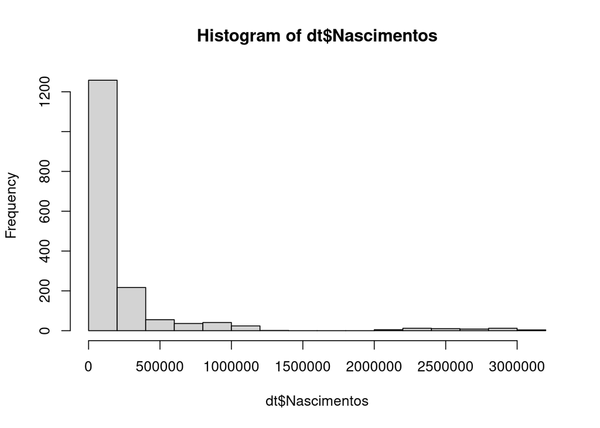

gráfico 2 - Nascimentos:

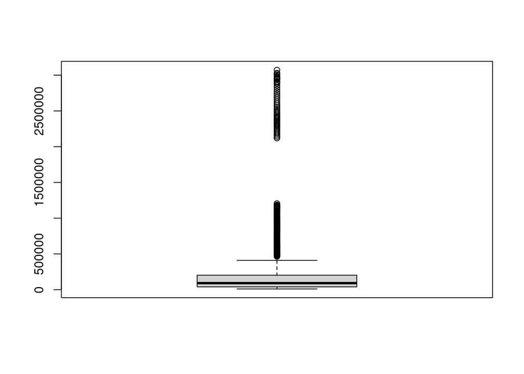

gráfico 1 - Obitos:

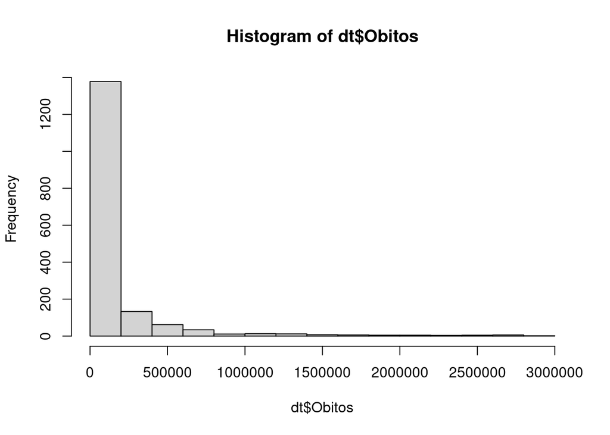

gráfico 2 - Obitos:

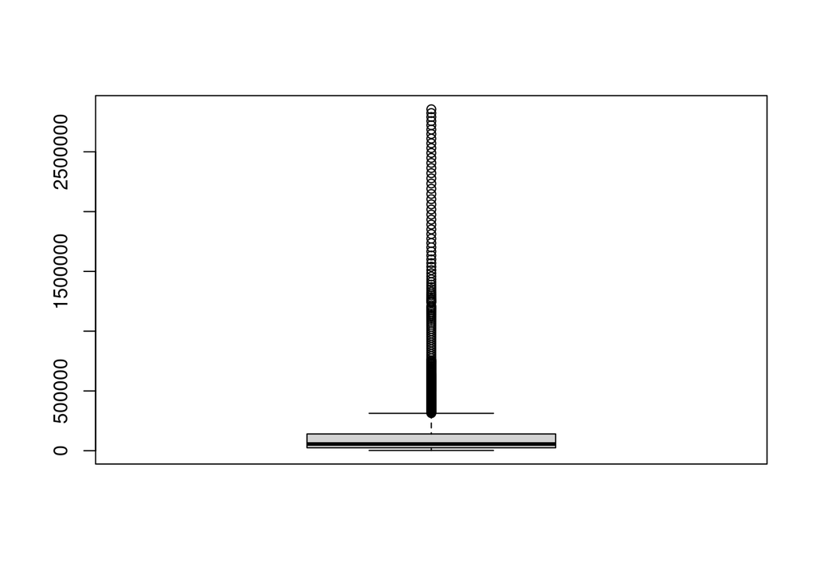

## Boxplot da Taxa de Fecundidade de 15 a 19 anos por Sigla_UF

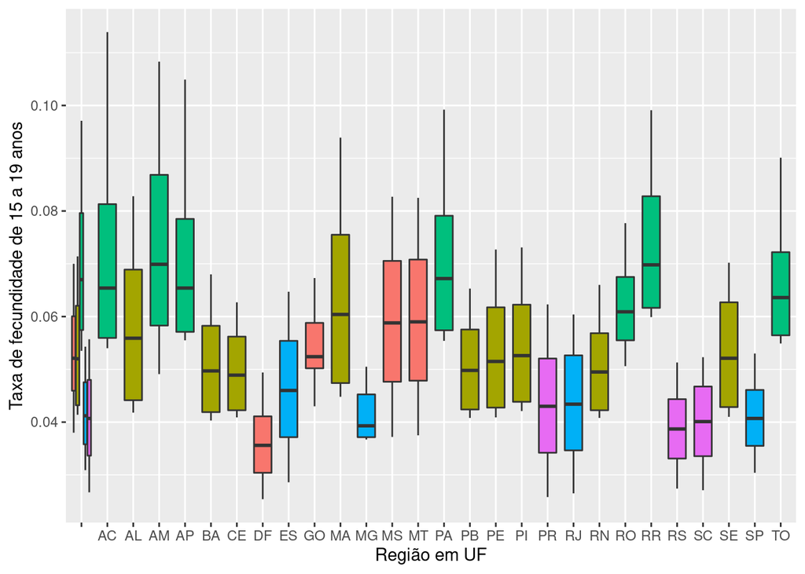

## Boxplot ìndice de Envelhecimento por Unidade da Federação

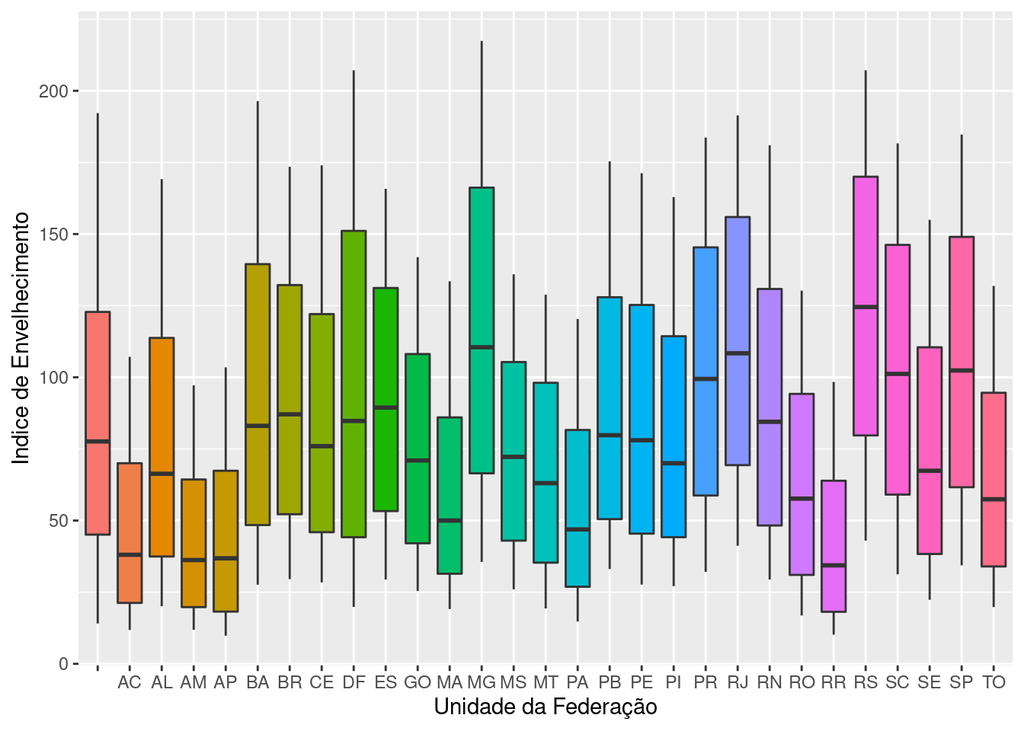

```r
ggplot2::ggplot(data = dt)+
  ggplot2::aes(x = Sigla_UF, y = Indice_Envelhecimento, fill = Sigla_UF)+
  ggplot2::geom_boxplot()+
  ggplot2::labs(
    x = 'Unidade da Federação',
    y = 'Indice de Envelhecimento'
  )+
  ggplot2::theme(legend.position = 'none')
```

#MAPA

Carregando banco de dados

```r
mapa <- rgdal::readOGR(
  dsn = "https://raw.githubusercontent.com/jonates/opendata/master/arquivos_geoespaciais/unidades_da_federacao.json",
  use_iconv = T
)
mapa@data
```

```
##              NM_ESTADO    NM_REGIAO CD_GEOCUF
## 0                 ACRE        NORTE        12
## 1              ALAGOAS     NORDESTE        27
## 2                AMAPÁ        NORTE        16
## 3             AMAZONAS        NORTE        13
## 4                BAHIA     NORDESTE        29
## 5                CEARÁ     NORDESTE        23
## 6     DISTRITO FEDERAL CENTRO-OESTE        53
## 7       ESPÍRITO SANTO      SUDESTE        32
## 8                GOIÁS CENTRO-OESTE        52
## 9             MARANHÃO     NORDESTE        21
## 10         MATO GROSSO CENTRO-OESTE        51
## 11  MATO GROSSO DO SUL CENTRO-OESTE        50
## 12        MINAS GERAIS      SUDESTE        31
## 13                PARÁ        NORTE        15
## 14             PARAÍBA     NORDESTE        25
## 15              PARANÁ          SUL        41
## 16          PERNAMBUCO     NORDESTE        26
## 17               PIAUÍ     NORDESTE        22
## 18      RIO DE JANEIRO      SUDESTE        33
## 19 RIO GRANDE DO NORTE     NORDESTE        24
## 20   RIO GRANDE DO SUL          SUL        43
## 21            RONDÔNIA        NORTE        11
## 22             RORAIMA        NORTE        14
## 23      SANTA CATARINA          SUL        42
## 24           SÃO PAULO      SUDESTE        35
## 25             SERGIPE     NORDESTE        28
## 26           TOCANTINS        NORTE        17
```

Transformando tipo da variável

```r
mapa@data$CD_GEOCUF<-as.integer(mapa@data$CD_GEOCUF)
```

Visualizar

```r
dplyr::glimpse(mapa@data)
```

```
## Rows: 27
## Columns: 3
## $ NM_ESTADO <chr> "ACRE", "ALAGOAS", "AMAPÁ", "AMAZONAS", "BAHIA", "CEARÁ", "D…
## $ NM_REGIAO <chr> "NORTE", "NORDESTE", "NORTE", "NORTE", "NORDESTE", "NORDESTE…
## $ CD_GEOCUF <int> 12, 27, 16, 13, 29, 23, 53, 32, 52, 21, 51, 50, 31, 15, 25, …
```

```r
mapa@data
```

```
##              NM_ESTADO    NM_REGIAO CD_GEOCUF
## 0                 ACRE        NORTE        12
## 1              ALAGOAS     NORDESTE        27
## 2                AMAPÁ        NORTE        16
## 3             AMAZONAS        NORTE        13
## 4                BAHIA     NORDESTE        29
## 5                CEARÁ     NORDESTE        23
## 6     DISTRITO FEDERAL CENTRO-OESTE        53
## 7       ESPÍRITO SANTO      SUDESTE        32
## 8                GOIÁS CENTRO-OESTE        52
## 9             MARANHÃO     NORDESTE        21
## 10         MATO GROSSO CENTRO-OESTE        51
## 11  MATO GROSSO DO SUL CENTRO-OESTE        50
## 12        MINAS GERAIS      SUDESTE        31
## 13                PARÁ        NORTE        15
## 14             PARAÍBA     NORDESTE        25
## 15              PARANÁ          SUL        41
## 16          PERNAMBUCO     NORDESTE        26
## 17               PIAUÍ     NORDESTE        22
## 18      RIO DE JANEIRO      SUDESTE        33
## 19 RIO GRANDE DO NORTE     NORDESTE        24
## 20   RIO GRANDE DO SUL          SUL        43
## 21            RONDÔNIA        NORTE        11
## 22             RORAIMA        NORTE        14
## 23      SANTA CATARINA          SUL        42
## 24           SÃO PAULO      SUDESTE        35
## 25             SERGIPE     NORDESTE        28
## 26           TOCANTINS        NORTE        17
```

Renomeando variável

```r
dt<-dplyr:: rename(dt, CD_GEOCUF = Codigo_UF)
```

Filtrando a base de dados pelo ano de 2025 e tirando o ‘Todas’ do Nome_UF

```r
dt %>%
  dplyr::filter(Ano == 2025 & Nome_UF != "Todas")->dt
```

Unindo banco

```r
mapa@data <- dplyr::left_join(
  x = mapa@data,
  y = dt,
  by = "CD_GEOCUF"
)

mapa@data%>%
  mutate(UF= case_when(
    CD_GEOCUF== 11 ~ "Rondônia (RO)",
    CD_GEOCUF== 12 ~ "Acre (AC)",
    CD_GEOCUF== 13 ~ "Amazonas (AM)",
    CD_GEOCUF== 14 ~ "Roraima (RR)",
    CD_GEOCUF== 15 ~ "Pará (PA)",
    CD_GEOCUF== 16 ~ "Amapá (AP)",
    CD_GEOCUF== 17 ~ "Tocantins (TO)",
    CD_GEOCUF== 21 ~ "Maranhão (MA)",
    CD_GEOCUF== 22 ~ "Piauí (PI)",
    CD_GEOCUF== 23 ~ "Ceará (CE)",
    CD_GEOCUF== 24 ~ "Rio Grande do Norte (RN)",
    CD_GEOCUF== 25 ~ "Paraíba (PB)",
    CD_GEOCUF== 26 ~ "Pernambuco (PE)",
    CD_GEOCUF== 27 ~ "Alagoas (AL)",
    CD_GEOCUF== 28 ~ "Sergipe (SE)",
    CD_GEOCUF== 29 ~ "Bahia (BA)",
    CD_GEOCUF== 31 ~ "Minas Gerais (MG)",
    CD_GEOCUF== 32 ~ "Espírito Santo (ES)",
    CD_GEOCUF== 33 ~ "Rio de Janeiro (RJ)",
    CD_GEOCUF== 35 ~ "São Paulo (SP)",
    CD_GEOCUF== 41 ~ "Paraná (PR)",
    CD_GEOCUF== 42 ~ "Santa Catarina (SC)",
    CD_GEOCUF== 43 ~ "Rio Grande do Sul (RS)",
    CD_GEOCUF== 50 ~ "Mato Grosso do Sul (MS)",
    CD_GEOCUF== 51 ~ "Mato Grosso (MT)",
    CD_GEOCUF== 52 ~ "Goiás (GO)",
    CD_GEOCUF== 53 ~ "Distrito Federal (DF)"
  )) ->mapa@data
```

##Paleta de cores do mapa

```r
library(viridis)
viridis(27)-> cores_27
```

Criando a paleta de cores do mapa

```r
paleta_regioes_pesquisas <- leaflet::colorFactor(
  palette = cores_27,
  domain = factor(
    x = mapa$Populacao_Total,
    levels= (mapa$Populacao_Total)
  ))
```

Formatando a variável ‘mapa@data$Populaçao_Total’ em milhar

```
mapa@data$Populacao_Total <- format(mapa@data$Populacao_Total, big.mark = ".", decimal.mark = ",")
```

## O mapa de distribuiçao da população por UF

[interactive chart not shown]

Dados do mapa

```r
dplyr::glimpse(mapa@data)
```

```
## Rows: 27
## Columns: 42
## $ NM_ESTADO              <chr> "ACRE", "ALAGOAS", "AMAPÁ", "AMAZONAS", "BAHIA"…
## $ NM_REGIAO              <chr> "NORTE", "NORDESTE", "NORTE", "NORTE", "NORDEST…
## $ CD_GEOCUF              <int> 12, 27, 16, 13, 29, 23, 53, 32, 52, 21, 51, 50,…
## $ X                      <int> 373, 985, 577, 424, 1087, 781, 1648, 1189, 1597…
## $ Pais                   <chr> "Brasil", "Brasil", "Brasil", "Brasil", "Brasil…
## $ Nome_Regiao            <chr> "Norte", "Nordeste", "Norte", "Norte", "Nordest…
## $ Codigo_Regiao          <int> 1, 2, 1, 1, 2, 2, 5, 3, 5, 2, 5, 5, 3, 1, 2, 4,…
## $ Nome_UF                <chr> "Acre", "Alagoas", "Amapá", "Amazonas", "Bahia"…
## $ Sigla_UF               <chr> "AC", "AL", "AP", "AM", "BA", "CE", "DF", "ES",…
## $ Ano                    <int> 2025, 2025, 2025, 2025, 2025, 2025, 2025, 2025,…
## $ Populacao_Total        <int> 955012, 3415514, 938973, 4510151, 15170253, 943…
## $ Populacao_Homens       <int> 476766, 1629433, 469931, 2259251, 7333933, 4566…
## $ Populacao_Mulheres     <int> 478246, 1786081, 469042, 2250900, 7836320, 4869…
```

[output cut: 29 more lines]

```r
class(mapa_1)
```

```
## [1] "leaflet"    "htmlwidget"
```